# Analyzing the amesHousing2011 Data

Author

Johnathan Pham

Published

April 29, 2024

# Obtaining the data

This section of the report loaded the $amesHousing2011.csv$ file. The file consisted of 82 variables and 2930 observations. After careful tweaking of the data, I have removed many variables and observations, and changed the type of some variables. I have also created the correct order for some ordered variables.

# Data Dictionary

- Type of Dwelling (MSSubClass): The type of dwelling of the house sold.
- General Zone (MSZoning): The general zoning classification of the house sold.
- Area of Lot (LotArea): The size of the lot in square feet of the house sold.
- Building Type (BldgType): The type of house sold.
- Style of House (HouseStyle): The style of the house sold.
- Overall House Quality (OverallQual): The overall rating of the material and finish of the house sold.
- Year Built (YearBuilt): The year that the house sold was originally constructed.
- Year Remodelled (YearRemod/Add): The year the house sold had a remodel (same as construction date if no remodeling or additions).
- External Quality (ExterQual): The quality of the exterior material of the house sold.
- Heating Quality (HeatingQC): The condition and quality of the heating of the house sold.
- Total Number of Rooms (TotRmsAbvGrd): The total number of rooms that are above grade, does not include bathrooms.
- Home Functionality (Functional): The amount of deductions received from each home, typical functionality with no deductions.
- Sale Price of the House (SalePrice): The price of the house when the house was sold.

# Data Description

## Part 1: Numerical Description

The following is the dataframe of amesHousing2011.csv, simplified to only 13 categories:

```
tibble [2,920 × 13] (S3: tbl_df/tbl/data.frame)
 $ MSSubClass   : Factor w/ 16 levels "020","030","040",..: 1 8 6 8 6 8 5 16 6 6 ...
 $ MSZoning     : Factor w/ 7 levels "A (agr)","C (all)",..: 6 6 6 7 6 7 6 5 6 6 ...
 $ LotArea      : num [1:2920] 47007 19800 35760 22950 17242 ...
 $ BldgType     : Factor w/ 5 levels "1Fam","2fmCon",..: 1 1 1 1 1 1 1 2 1 1 ...
 $ HouseStyle   : Factor w/ 8 levels "1.5Fin","1.5Unf",..: 3 5 6 4 6 4 1 4 6 6 ...
 $ OverallQual  : Ord.factor w/ 10 levels "10"<"9"<"8"<"7"<..: 6 5 1 1 2 4 3 5 1 3 ...
 $ YearBuilt    : num [1:2920] 1959 1935 1995 1892 1993 ...
 $ YearRemod/Add: num [1:2920] 1996 1990 1996 1993 1994 ...
 $ ExterQual    : Ord.factor w/ 5 levels "Ex"<"Gd"<"TA"<..: 3 3 2 2 2 3 3 4 1 1 ...
 $ HeatingQC    : Ord.factor w/ 5 levels "Ex"<"Gd"<"TA"<..: 3 2 1 1 1 1 1 1 1 1 ...
 $ TotRmsAbvGrd : num [1:2920] 11 7 10 12 11 10 11 14 10 12 ...
 $ Functional   : Ord.factor w/ 8 levels "Typ"<"Min1"<"Min2"<..: 1 1 1 1 1 1 1 1 1 4 ...
 $ SalePrice    : num [1:2920] 284700 415000 625000 475000 584500 ...
```

In the Type of Dwelling, the following summary is provided:

```
 020  030  040  045  050  060  070  075  080  085  090  120  150  160  180  190
1075  139    6   18  286  571  128   23  118   48  109  192    1  129   17   60
```

```
# A tibble: 16 × 3
   MSSubClass avPriceByClass     n
   <chr>               <dbl> <int>
 1 060               237810.   571
 2 120               208019.   192
 3 075               199978.    23
 4 020               187359.  1078
 5 080               168009.   118
 6 070               156526.   128
 7 085               149842.    48
 8 150               148400      1
 9 040               144917.     6
10 090               139809.   109
11 050               137433.   287
12 160               137080.   129
13 190               125870.    61
14 045               111783.    18
15 180               107671.    17
16 030                96727.   139
```

A post-WWII two story house (060) looks to be the most expensive, while a pre-WWII one story home (030) looks to be the least expensive.

We can table the General Zone (MSZoning) the same way.

```
# A tibble: 7 × 3
  MSZoning avPriceByClass     n
  <fct>             <dbl> <int>
1 FV              218987.   139
2 RL              190586.  2263
3 RH              136420.    27
4 RM              126781.   462
5 I (all)          80312.     2
6 C (all)          79795.    25
7 A (agr)          47300      2
```

This table is more obvious, as Floating Village Residential is the most expensive, since the cost of construction is more expensive. I chose to keep this variable because it shows a distinct difference of cost between a house built in a good zone compared to a house built in a worse zone.

```
      Ex  Gd  TA  Fa  Po
  10  24   2   0   0   0
  9   58  48   1   0   0
  8   15 325  10   0   0
  7    4 416 178   1   0
  6    2 143 583   3   0
  5    0  44 772   8   0
  4    0   6 209  11   0
  3    0   3  32   5   0
  2    0   0   9   4   0
  1    0   0   1   3   0
```

Above is a contingency table between Overall Quality and External Quality. We can see a correlation between a high overall quality and a high external quality, and same for a low overall quality and a low external quality. This table also shows us that most of the houses in this list have an overall quality rating of about 4-6, and an external quality of good and average/typical.

```
           2   3   4   5   6   7   8   9  10  11  12  13  14
  1.5Fin   0   1   7  47 110  90  34  13   7   1   2   0   0
  1.5Unf   0   0   7  10   2   0   0   0   0   0   0   0   0
  1Story   1  15 146 427 500 257  92  19  18   2   0   0   0
  2.5Fin   0   0   0   0   0   0   2   0   2   1   2   0   1
  2.5Unf   0   0   0   0   2   6   5   7   2   1   0   1   0
  2Story   0   1  21  51 148 264 199 100  49  25  11   0   0
  SFoyer   0   8  16  28  25   1   5   0   0   0   0   0   0
  SLvl     0   1   6  21  57  29   9   4   0   1   0   0   0
```

Looking at another contingency table between House Style and Total Number of Rooms, we can see that one-stories tend to have less rooms than two-stories, as expected. These variables can be used to find outliers in the data.

```
        10   9   8   7   6   5   4   3   2   1
  Typ   26 107 345 578 698 730 193  32   8   1
  Min1   0   0   1   7  12  34   7   3   1   0
  Min2   0   0   1   5  12  32  18   1   1   0
  Mod    0   0   1   4   3  17   7   2   0   1
  Maj1   0   0   2   5   3   6   0   0   2   1
  Maj2   0   0   0   0   2   4   0   2   1   0
  Sev    0   0   0   0   1   1   0   0   0   0
  Sal    0   0   0   0   0   0   1   0   0   1
```

Similarly, the Overall Quality can be compared to Home Functionality, and a higher functionality leads to a higher overall quality. As the functionality decreases, the overall quality also decreases. By comparing these two, outliers can be found, such as the Salvage Only houses and the Severe Damage houses.

```
# A tibble: 118 × 3
   YearBuilt avPriceByClass     n
       <dbl>          <dbl> <int>
 1      1893        325000      1
 2      2008        320359.    47
 3      1892        291250      2
 4      2010        283116      3
 5      2009        277097.    25
 6      2007        266677.   108
 7      2006        259624.   138
 8      1995        247500     31
 9      2005        241994.   142
10      1981        241150     10
# ℹ 108 more rows
```

The table above shows that newer houses, built around 2005-2009, tend to be higher in price than houses that were older. The YearBuilt variable is a good variable to keep since there is a distinct difference in price between newer houses and older houses.

```
# A tibble: 7 × 3
  MSZoning avPriceByClass     n
  <fct>             <dbl> <int>
1 I (all)          39190      2
2 A (agr)          31250      1
3 RL               10790.  2262
4 C (all)           8321.    25
5 RH                7362.    27
6 FV                6549.   139
7 RM                6410.   460
```

```
           2   3   4   5   6   7   8   9  10  11  12  13  14
  1Fam     1   8 135 446 717 598 292 129  53  27   7   0   0
  2fmCon   0   0   3  13  11  10   7   8   6   1   1   0   1
  Duplex   0   0   8   5  16   0  46   5  18   2   7   1   0
  Twnhs    0   5  18  33  29  15   0   1   0   0   0   0   0
  TwnhsE   0  13  38  87  70  23   1   0   1   0   0   0   0
```

```
         A (agr) C (all)   FV I (all)   RH   RL   RM
  1Fam         1      22   77       2   12 1999  300
  2fmCon       0       3    0       0    4   29   25
  Duplex       0       0    0       0    4   92   12
  Twnhs        0       0   19       0    1   28   53
  TwnhsE       0       0   43       0    6  114   70
```

With the table above, we can see that duplexes are found more in low density areas, and townhouses are found more in medium density areas.

Looking at the Building Type (BldgType), we can see that 82.7 percent of the homes sold were single-family homes.

```
  1Fam 2fmCon Duplex  Twnhs TwnhsE
  2420     62    109    101    233
```

## Part 2: Visual Description

### Introduction

In this section, we will observe multiple visual descriptions of plots in order to analyze the relationship between various different variables, in order to find the most important factors that affect Sale Price.

### Visual Data Plots

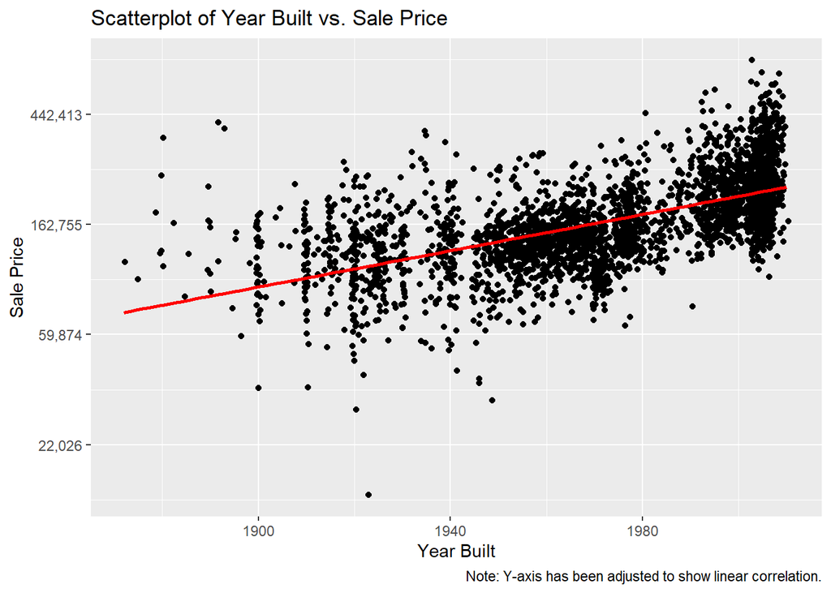

The plot above shows the relationship between Sale Price and Year Built. A positive linear correlation is illustrated between the two, meaning that as the year built increases, the sale price also increases. This plot showed me that YearBuilt is an essential variable to keep.

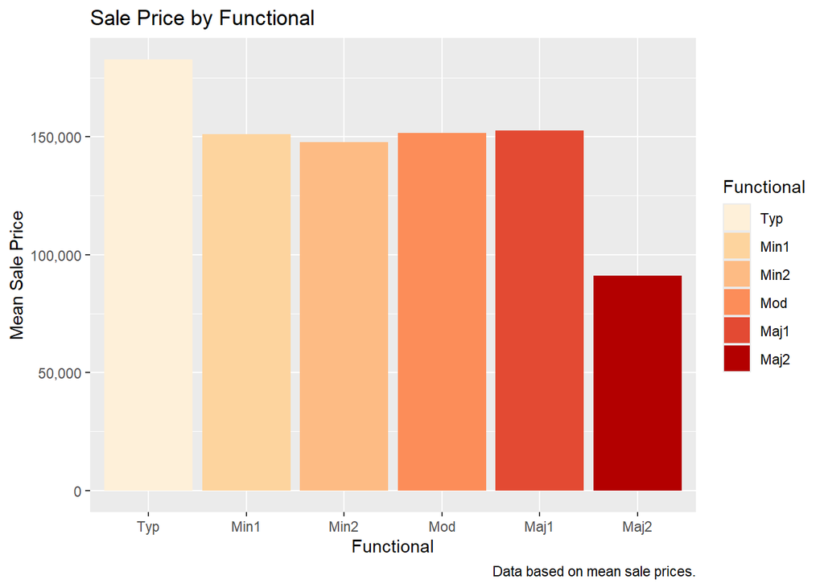

With the bar plot above, we can see that homes with typical functionality sell for more than homes that have deductions. The houses with minor deductions and moderate deductions seem to sell for around the same amount. Note that this graph does not include two properties that have severe or salvage functionalities, as they were removed as outliers. This graph made me want to keep Functional, since more deductions lead to a lower sell price.

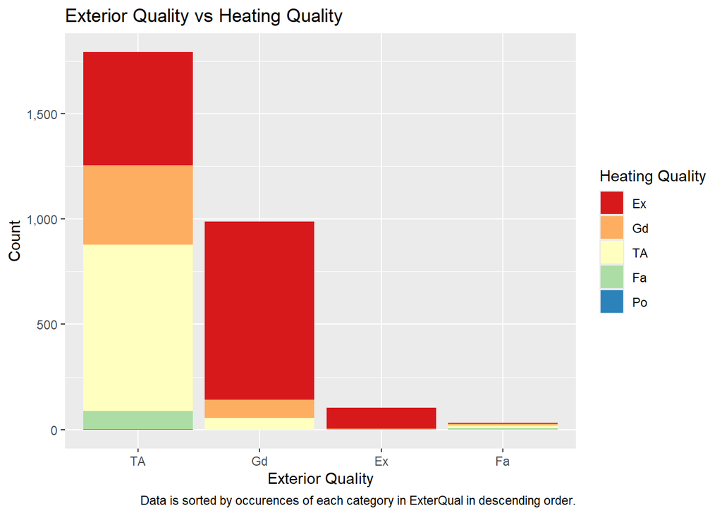

This stacked bar plot between ExterQual and HeatingQC shows us two things: a) Most of the houses in the dataframe have an Average/Typical exterior quality, and b) Good and Excellent exterior quality houses have high proportions of Excellent heating quality.

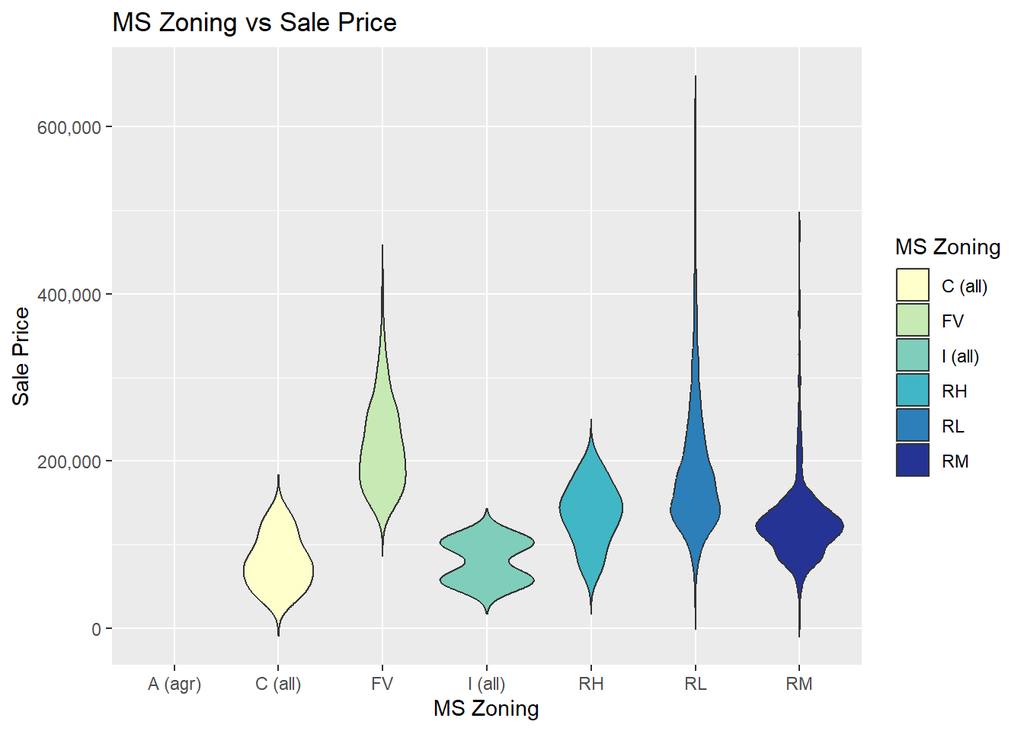

With the graph above, I noticed that homes that were in an Agriculture zone were removed, and this is probably due to removing Lot Areas that were greater than 60,000 square feet. This violin plot also visually shows that floating village zones have more expensive houses than industrial and commercial zones. It also shows that low density residential zones have a couple outliers that make the violin tall and long. The uniqueness of the MSZoning variable made me want to keep it, since analyzing it in the future seems interesting.

## Conclusion

After looking at these visual diagrams of the relationships between some of the variables, we can conclude that we found some variables that definitely affect the sale price. We also were able to find some other interesting things, such as homes in the agricultural zones were removed due to a filter of Lot Area earlier on.

# Regression Analysis

```
Call:
lm(formula = SalePrice ~ TotRmsAbvGrd + MSZoning, data = newdf)

Residuals:
    Min      1Q  Median      3Q     Max
-193744  -35755  -10529   22724  413577

Coefficients:
                Estimate Std. Error t value Pr(>|t|)
(Intercept)     -61915.9    64048.4  -0.967    0.334
TotRmsAbvGrd     23902.7      767.8  31.131   <2e-16 ***
MSZoningC (all)   3075.6    65147.8   0.047    0.962
MSZoningFV      135251.4    64111.9   2.110    0.035 *
MSZoningI (all)  10763.8    78240.7   0.138    0.891
MSZoningRH       43411.1    65055.8   0.667    0.505
MSZoningRL       96020.3    63898.0   1.503    0.133
MSZoningRM       45328.2    63951.9   0.709    0.479
---
Signif. codes:  0 '***' 0.001 '**' 0.01 '*' 0.05 '.' 0.1 ' ' 1

Residual standard error: 63880 on 2908 degrees of freedom
Multiple R-squared:  0.3373,    Adjusted R-squared:  0.3357
F-statistic: 211.4 on 7 and 2908 DF,  p-value: < 2.2e-16
```

The summary above shows the relationship between SalePrice and TotRmsAbvGrd and MSZoning. We can see that the number of rooms in a house significantly influences SalePrice, shown by the high coefficients, while the type of zoning is not very significant towards determining sale price. More rooms are associated with high sale prices, and floating village and low density areas means higher sale prices. Using this information, we can remove MSZoning from the list of variables that can help determine SalePrice.

## Model 2: Year Built

```
Call:
lm(formula = SalePrice ~ YearBuilt, data = newdf)

Residuals:
    Min      1Q  Median      3Q     Max
-146669  -40783  -14131   23374  410965

Coefficients:
              Estimate Std. Error t value Pr(>|t|)
(Intercept) -2.710e+06  7.803e+04  -34.73   <2e-16 ***
YearBuilt    1.466e+03  3.958e+01   37.05   <2e-16 ***
---
Signif. codes:  0 '***' 0.001 '**' 0.01 '*' 0.05 '.' 0.1 ' ' 1

Residual standard error: 64640 on 2914 degrees of freedom
Multiple R-squared:  0.3202,    Adjusted R-squared:  0.3199
F-statistic:  1372 on 1 and 2914 DF,  p-value: < 2.2e-16
```

## Model 3: OLSRR Subset Regression

```
                      Best Subsets Regression
--------------------------------------------------------------------
Model Index    Predictors
--------------------------------------------------------------------
     1         OverallQual
     2         OverallQual ExterQual
     3         HouseStyle OverallQual ExterQual
     4         HouseStyle OverallQual ExterQual HeatingQC
     5         HouseStyle OverallQual ExterQual HeatingQC Functional
--------------------------------------------------------------------

                                                                Subsets Regression Summary
-----------------------------------------------------------------------------------------------------------------------------------------------------------
                       Adj.        Pred
Model    R-Square    R-Square    R-Square      C(p)         AIC           SBIC          SBC            MSEP              FPE              HSP         APC
-----------------------------------------------------------------------------------------------------------------------------------------------------------
  1        0.7163      0.7154      0.7136    254.1612    70345.4766    62053.9187    70411.2342    5.084388e+12    1749616383.9856    600211.8762    0.2841
  2        0.7284      0.7273      0.7248    125.0475    70223.6448    61928.1960    70307.3364    4.867984e+12    1676878505.6540    575259.3046    0.2721
  3        0.7338      0.7320      0.7288     79.7761    70179.7496    61872.3921    70305.2870    4.773926e+12    1648451644.5634    565507.8982    0.2669
  4        0.7382      0.7361      0.7328     38.9438    70139.1720    61825.9536    70288.6212    4.696669e+12    1624015897.7285    557125.7734    0.2627
  5        0.7400      0.7375      0.7336     29.0000    70129.0972    61807.9680    70308.4362     4.66605e+12    1616220421.7347    554452.2839    0.2611
-----------------------------------------------------------------------------------------------------------------------------------------------------------
AIC: Akaike Information Criteria
 SBIC: Sawa's Bayesian Information Criteria
 SBC: Schwarz Bayesian Criteria
 MSEP: Estimated error of prediction, assuming multivariate normality
 FPE: Final Prediction Error
 HSP: Hocking's Sp
 APC: Amemiya Prediction Criteria
```

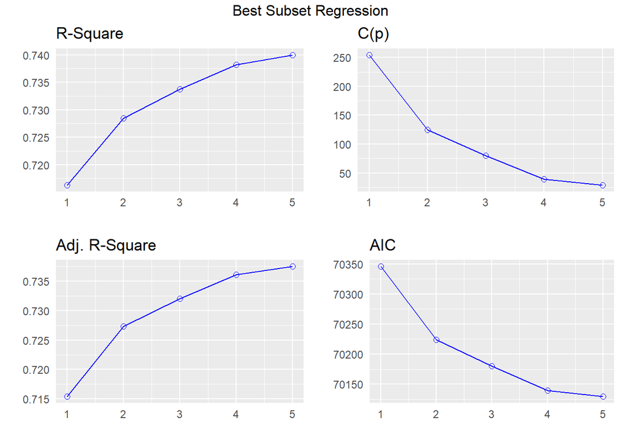

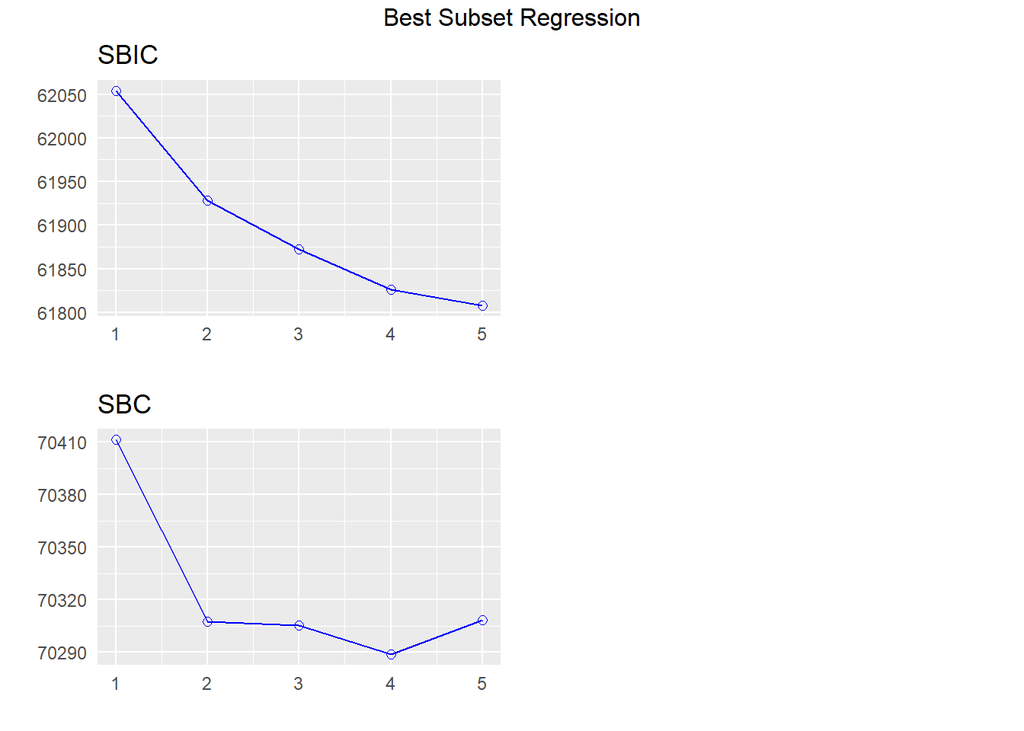

Based on the `ols_step_best_subset()` used above, the index with the largest increase in R-squared value shows that it is the best model with the variables in the linear model. We can create a model with those variables.

```
Call:
lm(formula = SalePrice ~ OverallQual + ExterQual, data = newdf)

Residuals:
    Min      1Q  Median      3Q     Max
-202006  -23446   -2636   18877  257554

Coefficients:
               Estimate Std. Error t value Pr(>|t|)
(Intercept)    193428.7     3115.1  62.094  < 2e-16 ***
OverallQual.L -331704.2    14667.2 -22.615  < 2e-16 ***
OverallQual.Q  109871.5    13983.3   7.857 5.48e-15 ***
OverallQual.C  -19381.2    12058.6  -1.607   0.1081
OverallQual^4   11590.0    10055.9   1.153   0.2492
OverallQual^5   20955.5     8191.0   2.558   0.0106 *
OverallQual^6   -2464.9     6606.8  -0.373   0.7091
OverallQual^7    2372.9     5081.3   0.467   0.6405
OverallQual^8    3834.4     3519.4   1.089   0.2760
OverallQual^9     220.4     2103.5   0.105   0.9165
ExterQual.L     -3330.8     5242.3  -0.635   0.5252
ExterQual.Q    -45742.9     5252.8  -8.708  < 2e-16 ***
ExterQual.C    -23860.7     4283.9  -5.570 2.78e-08 ***
---
Signif. codes:  0 '***' 0.001 '**' 0.01 '*' 0.05 '.' 0.1 ' ' 1

Residual standard error: 40930 on 2903 degrees of freedom
Multiple R-squared:  0.7284,    Adjusted R-squared:  0.7273
F-statistic: 648.9 on 12 and 2903 DF,  p-value: < 2.2e-16
```

## Model 4: Manually Specified

```
Call:
lm(formula = SalePrice ~ OverallQual + ExterQual + TotRmsAbvGrd +
    YearBuilt, data = newdf)

Residuals:
    Min      1Q  Median      3Q     Max
-202534  -19538   -1484   15885  261763

Coefficients:
               Estimate Std. Error t value Pr(>|t|)
(Intercept)   -765579.3    59746.5 -12.814  < 2e-16 ***
OverallQual.L -252569.8    13261.5 -19.045  < 2e-16 ***
OverallQual.Q  109987.8    12362.4   8.897  < 2e-16 ***
OverallQual.C  -23009.0    10683.1  -2.154   0.0313 *
OverallQual^4    9495.7     8891.2   1.068   0.2856
OverallQual^5   14391.1     7245.1   1.986   0.0471 *
OverallQual^6   -5576.3     5845.0  -0.954   0.3401
OverallQual^7   -3005.6     4498.3  -0.668   0.5041
OverallQual^8    3762.8     3115.4   1.208   0.2272
OverallQual^9   -2444.9     1863.3  -1.312   0.1896
ExterQual.L     -2710.6     4642.9  -0.584   0.5594
ExterQual.Q    -36116.4     4748.3  -7.606 3.79e-14 ***
ExterQual.C    -22938.1     3790.6  -6.051 1.62e-09 ***
TotRmsAbvGrd    12336.9      471.5  26.166  < 2e-16 ***
YearBuilt         448.4       30.1  14.899  < 2e-16 ***
---
Signif. codes:  0 '***' 0.001 '**' 0.01 '*' 0.05 '.' 0.1 ' ' 1

Residual standard error: 36180 on 2901 degrees of freedom
Multiple R-squared:  0.7879,    Adjusted R-squared:  0.7869
F-statistic: 769.8 on 14 and 2901 DF,  p-value: < 2.2e-16
```

This model takes the best explanatory variables from the models above. Almost every variable is statistically significant in explaining SalePrice. There is also a high R-sqaured value, meaning that the model explains around 79% of the variability observed in SalePrice.

## Conclusion

# Regression Diagnostics

```
Call:
lm(formula = SalePrice ~ OverallQual + ExterQual + TotRmsAbvGrd +
    YearBuilt, data = newdf)

Residuals:
    Min      1Q  Median      3Q     Max
-202534  -19538   -1484   15885  261763

Coefficients:
               Estimate Std. Error t value Pr(>|t|)
(Intercept)   -765579.3    59746.5 -12.814  < 2e-16 ***
OverallQual.L -252569.8    13261.5 -19.045  < 2e-16 ***
OverallQual.Q  109987.8    12362.4   8.897  < 2e-16 ***
OverallQual.C  -23009.0    10683.1  -2.154   0.0313 *
OverallQual^4    9495.7     8891.2   1.068   0.2856
OverallQual^5   14391.1     7245.1   1.986   0.0471 *
OverallQual^6   -5576.3     5845.0  -0.954   0.3401
OverallQual^7   -3005.6     4498.3  -0.668   0.5041
OverallQual^8    3762.8     3115.4   1.208   0.2272
OverallQual^9   -2444.9     1863.3  -1.312   0.1896
ExterQual.L     -2710.6     4642.9  -0.584   0.5594
ExterQual.Q    -36116.4     4748.3  -7.606 3.79e-14 ***
ExterQual.C    -22938.1     3790.6  -6.051 1.62e-09 ***
TotRmsAbvGrd    12336.9      471.5  26.166  < 2e-16 ***
YearBuilt         448.4       30.1  14.899  < 2e-16 ***
---
Signif. codes:  0 '***' 0.001 '**' 0.01 '*' 0.05 '.' 0.1 ' ' 1

Residual standard error: 36180 on 2901 degrees of freedom
Multiple R-squared:  0.7879,    Adjusted R-squared:  0.7869
F-statistic: 769.8 on 14 and 2901 DF,  p-value: < 2.2e-16
```

Above is a reprint of the model 4 that we found above. Overall, the model seems to fit the data reasonably well, explaining a significant portion of the variance in sale prices.

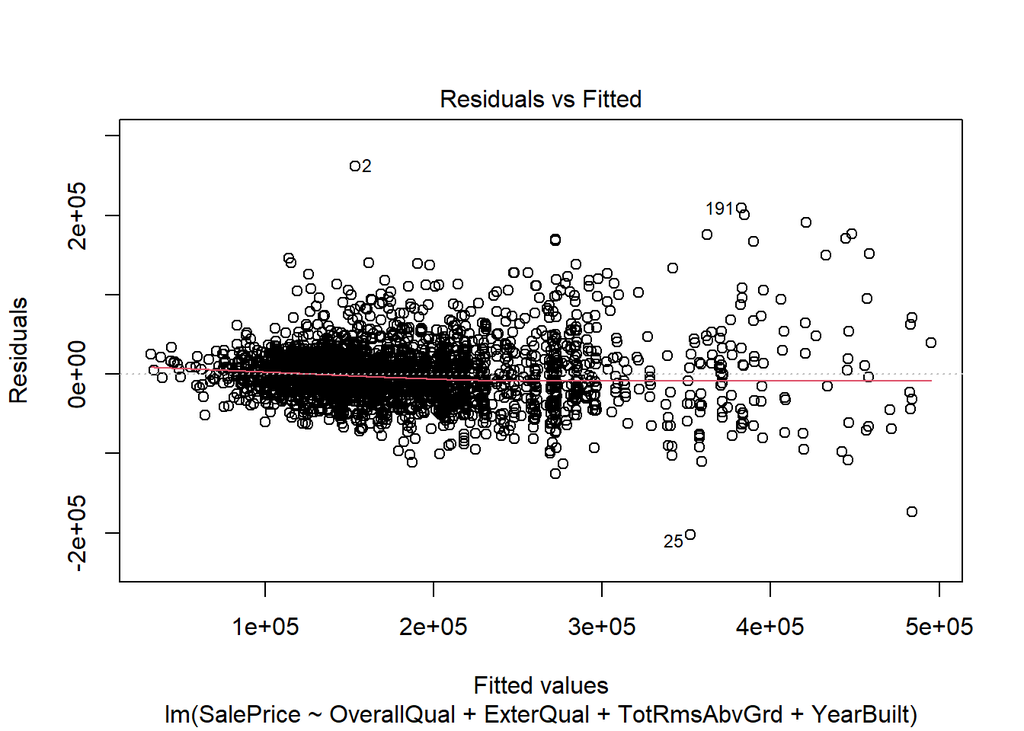

The plot above shows the difference between the residuals and the fitted values. Looking at the plot, I don’t see many outliers except the possibility of 2 and 25. We can also see that the red solid line is close to the dotted dashed line. This means that the mean of the residuals have a mean of approximately zero. We can also cancel out any thoughts of a pattern, except for the fact that there are a bunch more dots on the left than on the right.

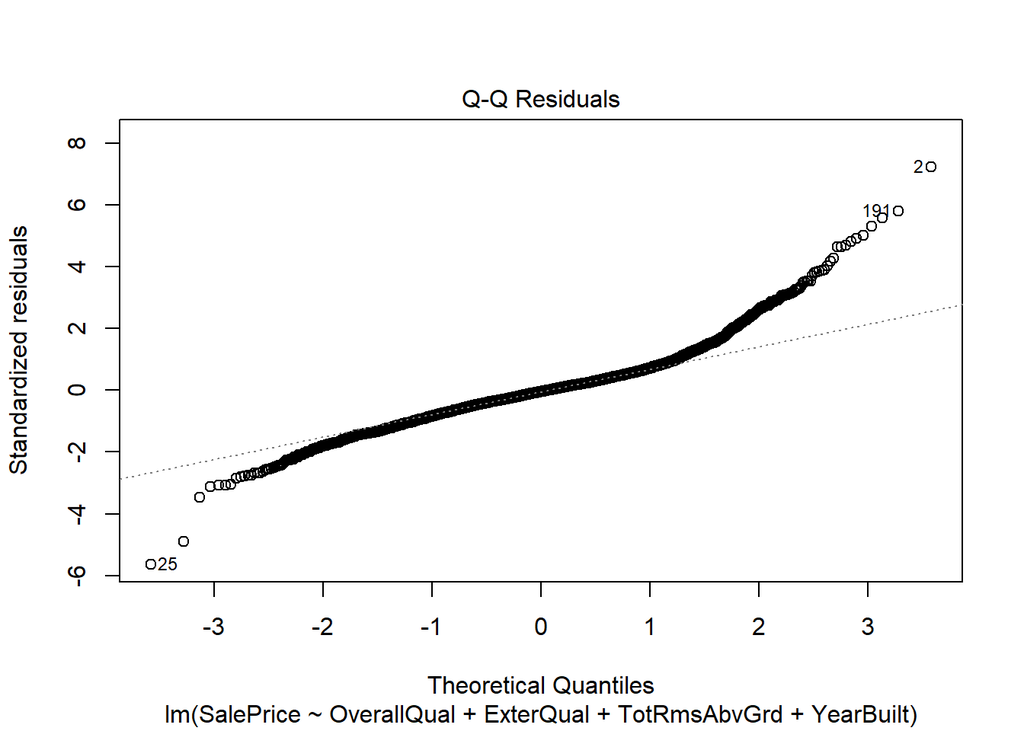

Looking at this Q-Q graph, we can see that the dots somewhat follow the dashed line. Towards the extremes of the graph, it seems to veer away from the dashed line, but the use of this graph tells us that the residuals should be normally distributed.

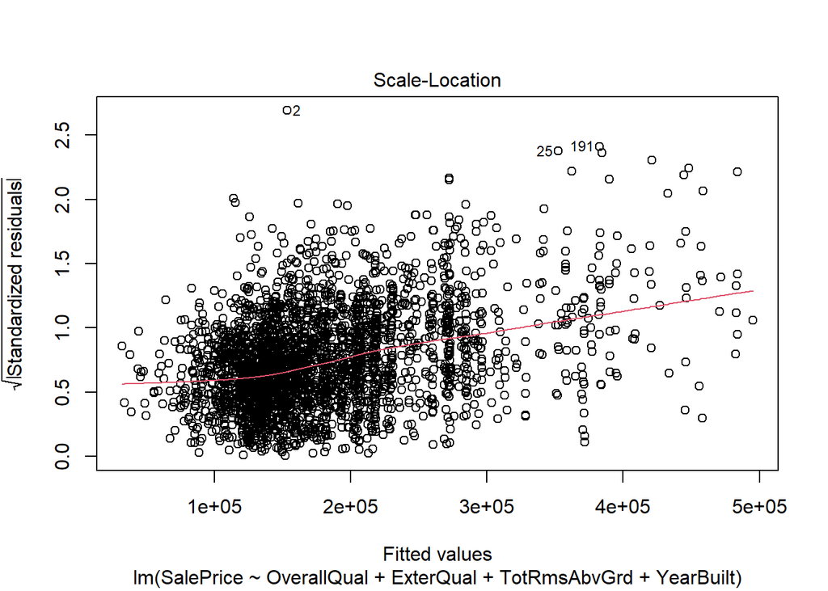

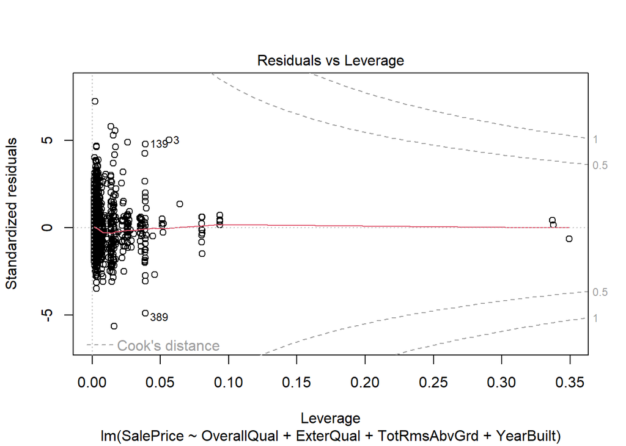

This plot shows the residuals vs leverage graph. Using this graph, we can find influential points that we may want to remove. The dotted lines at the top and bottom of the graph represent Cook’s distance, and since none of the points are past those lines, there are not many influential points.

## Conclusion

The diagnostic plots were used to find if the calculated model and the assumptions we made about the data and the model are consistent with the recorded data. From the diagnostic plots that we used, we can see that the model that we found earlier was a good model, since there weren’t many problems with the plots that we found.

# Report Summary

In this report, we analyzed the data from $amesHousing2011.csv$ in order to find the best predictors for sale price. We filtered through countless variables and observations in order to remove outliers and unimportant variables. We created numerical and visual descriptions for some of these variables. We then created a model using some of these variables, in order to find variables that were significant in determining sale price. After a model was created, we used regression diagnostics to determine if the model was a good fit for the data.

After all of these steps, we found 4 variables that were the best predictors to sale price:

- OverallQual (Overall Quality)
- ExterQual (External Quality)
- TotRmsAbvGrd (Total Number of Rooms)
- YearBuilt (Year Built)